# EasyVisa_KimAbernathy_FullCodeProject (2)

## Data Pre-Processing

### Outlier Check

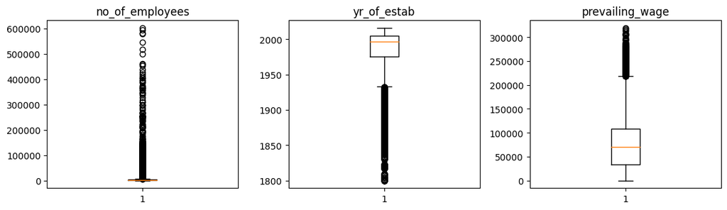

```python
# outlier detection using boxplot
numeric_columns = data.select_dtypes(include=np.number).columns.tolist()
plt.figure(figsize=(15, 12))

for i, variable in enumerate(numeric_columns):
    plt.subplot(4, 4, i + 1)
    plt.boxplot(data[variable], whis=1.5)
    plt.tight_layout()
    plt.title(variable)

plt.show()
```

#### Observations on Outliers

- `no_of_employees` has many extreme outliers, with values well above 100,000. Most data points are concentrated near the lower end.
- `yr_of_estab` shows a large cluster of older companies (pre-1950) that appear as lower-end outliers. Most companies were founded after 1980.
- `prevailing_wage` has many high-wage outliers above 200K. The majority of values are concentrated below 100K.
- I chose not to remove outliers because I’ll be using decision tree-based models, which are robust to outliers by design. Additionally, there are a significant number of upper outliers, and many of them may represent valid cases (e.g., large companies or high-paying roles), so I believe it’s better to retain them rather than risk losing meaningful information.

### Data Preparation for Modeling

- We want to predict which visa will be certified.
- Before creating a model, we need to **normalize the unit of wage to Yearly**, **convert binary variables**, and **encode categorical features**.
- We'll split the data into train and test to be able to evaluate the model that we build on the train data.

```python
# Normalize unit_of_wage to Yearly

conversion_factors = {
    "Hour": 2080,   # 40 hours/week * 52 weeks
    "Week": 52,     # 52 weeks/year
    "Month": 12,    # 12 months/year
    "Year": 1       # Already yearly
}

# Create new column, 'normalized_wage'
data["normalized_wage"] = data.apply(
    lambda row: row["prevailing_wage"] * conversion_factors.get(row["unit_of_wage"], 1),
    axis=1
)

# Drop original 'prevailing_wage' and 'unit_of_wage' columns
data.drop(["prevailing_wage", "unit_of_wage"], axis=1, inplace=True)
```

- This step normalizes `unit_of_wage` into the same unit, Yearly.

```python
# Convert case_status to binary (Certified = 1, Denied = 0)
data["case_status"] = data["case_status"].apply(lambda x: 1 if x == "Certified" else 0)

# Convert has_job_experience to binary (Yes = 1, No = 0)
data["has_job_experience"] = data["has_job_experience"].apply(lambda x: 1 if x == "Y" else 0)

# Convert requires_job_training to binary (Yes = 1, No = 0)
data["requires_job_training"] = data["requires_job_training"].apply(lambda x: 1 if x == "Y" else 0)

# Convert full_time_position to binary (Yes = 1, No = 0)
data["full_time_position"] = data["full_time_position"].apply(lambda x: 1 if x == "Y" else 0)

# Drop case_status from feature set
X = data.drop("case_status", axis=1)
y = data["case_status"]

# Create dummy variables for categorical columns
X = pd.get_dummies(X, drop_first=True)

# Split into train and validation sets (70% train, 30% val)
X_train, X_val, y_train, y_val = train_test_split(
    X, y, test_size=0.3, random_state=1, stratify=y
)

# Split validation set into validation and test (90% val, 10% test)
X_val, X_test, y_val, y_test = train_test_split(
    X_val, y_val, test_size=0.1, random_state=1, stratify=y_val
)
```

- This step converts binary features into numerical features so they don't need dummy variables.
- It also drops `case_status` from the dataset, as it's our target variable.
- It also utilizes one-hot encoding to create dummy variables for the remaining categorical features.

```python
print("Shape of Training set : ", X_train.shape)
print("Shape of Validation set : ", X_val.shape)
print("Shape of test set : ", X_test.shape)
print("Percentage of classes in training set:")
print(y_train.value_counts(normalize=True))
print("Percentage of classes in validation set:")
print(y_val.value_counts(normalize=True))
print("Percentage of classes in test set:")
print(y_test.value_counts(normalize=True))
```

```
Shape of Training set :  (17836, 18)
Shape of Validation set :  (6879, 18)
Shape of test set :  (765, 18)
Percentage of classes in training set:
1    0.667919
0    0.332081
Name: case_status, dtype: float64
Percentage of classes in validation set:
1    0.66783
0    0.33217
Name: case_status, dtype: float64
Percentage of classes in test set:
1    0.667974
0    0.332026
Name: case_status, dtype: float64
```

- This step confirms the splitting of our dataset into train, test, and validation sets.

```python
X.head()
```

|  | has_job_experience | requires_job_training | no_of_employees | yr_of_estab | full_time_position | normalized_wage | continent_Asia | continent_Europe | continent_North America | continent_Oceania | continent_South America | education_of_employee_Doctorate | education_of_employee_High School | education_of_employee_Master's | region_of_employment_Midwest | region_of_employment_Northeast | region_of_employment_South | region_of_employment_West |
| --- | --- | --- | --- | --- | --- | --- | --- | --- | --- | --- | --- | --- | --- | --- | --- | --- | --- | --- |
| 0 | 0 | 0 | 14513 | 2007 | 1 | 1231782.032 | 1 | 0 | 0 | 0 | 0 | 0 | 1 | 0 | 0 | 0 | 0 | 1 |
| 1 | 1 | 0 | 2412 | 2002 | 1 | 83425.650 | 1 | 0 | 0 | 0 | 0 | 0 | 0 | 1 | 0 | 1 | 0 | 0 |
| 2 | 0 | 1 | 44444 | 2008 | 1 | 122996.860 | 1 | 0 | 0 | 0 | 0 | 0 | 0 | 0 | 0 | 0 | 0 | 1 |
| 3 | 0 | 0 | 98 | 1897 | 1 | 83434.030 | 1 | 0 | 0 | 0 | 0 | 0 | 0 | 0 | 0 | 0 | 0 | 1 |
| 4 | 1 | 0 | 1082 | 2005 | 1 | 149907.390 | 0 | 0 | 0 | 0 | 0 | 0 | 0 | 1 | 0 | 0 | 1 | 0 |

#### Data Pre-Processing Observations

- I chose to convert features with Y/N values to binary numerical values (0/1) to reduce the number of columns created during one-hot encoding and keep the feature set simpler and more efficient for modeling.
- Using the .head() method above, I verified that the binary conversions and one-hot encoding were successfully applied.
- I also confirmed that the normalized_wage column was added and the case_status target column was excluded from the feature set.

## Model Building

### Which Evaluation Metric Will I Use?:

- The business goal is to correctly **identify applicants who are likely to be certified**, while **avoiding misclassification of those who should be denied**.
- I'm choosing **F1 Score** as the primary evaluation metric because it balances both **Precision and Recall**, which is important for this classification problem.
- **False positives** (certifying someone who should be denied) and **false negatives** (denying someone who could be certified) both have real-world consequences. A balanced metric like F1 Score helps address both.
- There is also a **moderate class imbalance** in the target variable (case_status), with about 67% of cases being Certified and 33% Denied. **Accuracy alone could be misleading in this context.**

```python
# Define function to compute performance metrics for classification model

def model_performance_classification_sklearn(model, predictors, target):
    """
    Function to compute different metrics to check classification model performance

    model: classifier
    predictors: independent variables
    target: dependent variable
    """

    # Predict using independent variables
    pred = model.predict(predictors)

    acc = accuracy_score(target, pred)         # Compute Accuracy
    recall = recall_score(target, pred)        # Compute Recall
    precision = precision_score(target, pred)  # Compute Precision
    f1 = f1_score(target, pred)                # Compute F1-score

    # Creating dataframe of metrics
    df_perf = pd.DataFrame(
        {"Accuracy": acc, "Recall": recall, "Precision": precision, "F1": f1,},
        index=[0],
    )

    return df_perf
```

```python
# Define function to create confusion matrix

def confusion_matrix_sklearn(model, predictors, target):
    """
    To plot the confusion_matrix with percentages

    model: classifier
    predictors: independent variables
    target: dependent variable
    """
    y_pred = model.predict(predictors)
    cm = confusion_matrix(target, y_pred)
    labels = np.asarray(
        [
            ["{0:0.0f}".format(item) + "\n{0:.2%}".format(item / cm.flatten().sum())]
            for item in cm.flatten()
        ]
    ).reshape(2, 2)

    plt.figure(figsize=(6, 4))
    sns.heatmap(cm, annot=labels, fmt="")
    plt.ylabel("True label")
    plt.xlabel("Predicted label")
```

#### Defining Scorer For Cross-Validation and Hyperparameter Tuning

```python
# Define F1 score as the evaluation metric for model tuning.
scorer = metrics.make_scorer(metrics.f1_score)
```

- I have applied my key performance metric, F1 Score.

### Model Building Using Original Data

```python
models = []  # Empty list to store all models

# Appending models into list
models.append(("Bagging", BaggingClassifier(random_state=1)))
models.append(("Random forest", RandomForestClassifier(random_state=1)))
models.append(("GBM", GradientBoostingClassifier(random_state=1)))
models.append(("Adaboost", AdaBoostClassifier(random_state=1)))
models.append(("Xgboost", XGBClassifier(random_state=1, eval_metric="logloss")))
models.append(("dtree", DecisionTreeClassifier(random_state=1)))

results1 = []  # Empty list to store all model CV scores
names = []     # Empty list to store name of models

# Loop through all models to get mean cross-validated score
print("\nCross-Validation Performance on Training Dataset:\n")

for name, model in models:
    kfold = StratifiedKFold(n_splits=5, shuffle=True, random_state=1)  # 5-fold CV
    cv_result = cross_val_score(
        estimator=model, X=X_train, y=y_train, scoring=scorer, cv=kfold
    )
    results1.append(cv_result)
    names.append(name)
    print("{}: {}".format(name, cv_result.mean()))

print("\nValidation Performance:\n")

for name, model in models:
    model.fit(X_train, y_train)  # Fit model on training data
    scores = f1_score(y_val, model.predict(X_val))  # Evaluate on validation set
    print("{}: {}".format(name, scores))
```

```
Cross-Validation Performance on Training Dataset:

Bagging: 0.7737683500847006
Random forest: 0.8002763453794746
GBM: 0.819460827255206
Adaboost: 0.8155205845647009
Xgboost: 0.8071535268739292
dtree: 0.7381787312216336

Validation Performance:

Bagging: 0.7641622268130912
Random forest: 0.7959929041010122
GBM: 0.8139201637666326
Adaboost: 0.8123872519542995
Xgboost: 0.8017384105960265
dtree: 0.7307734624271097
```

- In this step, I trained and evaluated six classification models using the original data. Each model was assessed using 5-fold cross-validation on the training data to estimate generalization performance.

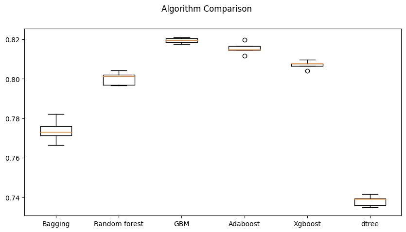

```python
# Plotting boxplots for CV scores of all models defined above
fig = plt.figure(figsize=(10, 5))

fig.suptitle("Algorithm Comparison")
ax = fig.add_subplot(111)

plt.boxplot(results1)
ax.set_xticklabels(names)

plt.show()
```

#### Model Benchmarking Results - Original Data

1. **Gradient Boosting (GBM):**
- CV: 0.82
- Validation: 0.81
2. **AdaBoost:**
- CV: 0.82
- Validation: 0.81
3. **XGBoost also performed strongly:**
- CV: 0.81
- Validation: 0.80

### Model Building Using Oversampled Data

- Oversampling will help the model learn the patterns of Denied cases (the minority class) better.

```python
print("Before OverSampling, counts of label '1': {}".format(sum(y_train == 1)))
print("Before OverSampling, counts of label '0': {} \n".format(sum(y_train == 0)))

# Synthetic Minority Over Sampling Technique
sm = SMOTE(sampling_strategy='auto', k_neighbors=5, random_state=1)
X_train_oversampled, y_train_oversampled = sm.fit_resample(X_train, y_train)

print("After OverSampling, counts of label '1': {}".format(sum(y_train_oversampled == 1)))
print("After OverSampling, counts of label '0': {} \n".format(sum(y_train_oversampled == 0)))

print("After OverSampling, the shape of train_X: {}".format(X_train_oversampled.shape))
print("After OverSampling, the shape of train_y: {} \n".format(y_train_oversampled.shape))
```

```
Before OverSampling, counts of label '1': 11913
Before OverSampling, counts of label '0': 5923

After OverSampling, counts of label '1': 11913
After OverSampling, counts of label '0': 11913

After OverSampling, the shape of train_X: (23826, 18)
After OverSampling, the shape of train_y: (23826,)
```

- In this step, I used the SMOTE oversampling method to create synthetic data to balance the minority class (Denied).
- Now, there are 23,826 training rows total, equally split between Certified(1) and Denied (0). Each row has 18 features.

```python
models = []  # Empty list to store all the models

# Appending models into list
models.append(("Bagging", BaggingClassifier(random_state=1)))
models.append(("Random forest", RandomForestClassifier(random_state=1)))
models.append(("GBM", GradientBoostingClassifier(random_state=1)))
models.append(("Adaboost", AdaBoostClassifier(random_state=1)))
models.append(("Xgboost", XGBClassifier(random_state=1, eval_metric="logloss")))
models.append(("dtree", DecisionTreeClassifier(random_state=1)))

results1 = []  # Empty list to store all model CV scores
names = []     # Empty list to store name of models

# Loop through all models to get mean cross-validated score
print("\nCross-Validation Performance on Training Dataset:\n")

for name, model in models:
    kfold = StratifiedKFold(n_splits=5, shuffle=True, random_state=1)  # 5-fold CV
    cv_result = cross_val_score(
        estimator=model, X=X_train_oversampled, y=y_train_oversampled, scoring=scorer, cv=kfold
    )
    results1.append(cv_result)
    names.append(name)
    print("{}: {}".format(name, cv_result.mean()))

print("\nValidation Performance:\n")

for name, model in models:
    model.fit(X_train_oversampled, y_train_oversampled)  # Fit model on oversampled training data
    scores = f1_score(y_val, model.predict(X_val))       # Evaluate on original validation set
    print("{}: {}".format(name, scores))
```

```
Cross-Validation Performance on Training Dataset:

Bagging: 0.7623811470534795
Random forest: 0.7884560746689021
GBM: 0.795876758865492
Adaboost: 0.780751339379742
Xgboost: 0.7936226748593003
dtree: 0.7287896417795261

Validation Performance:

Bagging: 0.7527839643652561
Random forest: 0.7835669198673371
GBM: 0.7966573816155988
Adaboost: 0.7781664016958134
Xgboost: 0.790594216714331
dtree: 0.7305521743941573
```

- In this step, I trained and evaluated six classification models using the oversampled dataset. Each model was assessed using 5-fold cross-validation on the training data to estimate generalization performance.

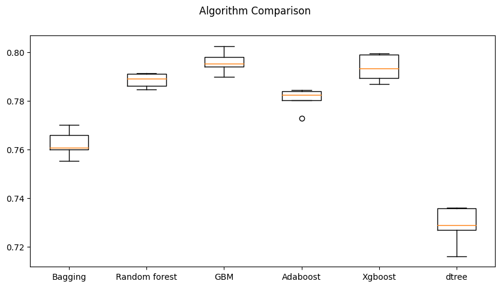

```python
# Plotting boxplots for CV scores of all models defined above
fig = plt.figure(figsize=(10, 5))

fig.suptitle("Algorithm Comparison")
ax = fig.add_subplot(111)

plt.boxplot(results1)
ax.set_xticklabels(names)

plt.show()
```

#### Model Benchmarking Results - Oversampled Data

The ensemble/boosting methods continued to perform well after balancing the class distribution with SMOTE, although there was a slight decrease in F1 scores compared to models trained on original data.

These were the top 3 models based on performance:

1. **Gradient Boosting (GBM):**
- CV: 0.796
- Validation: 0.797
2. **XGBoost:**
- CV: 0.794
- Validation: 0.791
3. **Random Forest:**
- CV: 0.788
- Validation: 0.784

### Model Building Using Undersampled Data

```python
rus = RandomUnderSampler(random_state=1, sampling_strategy=1)
X_train_undersampled, y_train_undersampled = rus.fit_resample(X_train, y_train)

print("Before UnderSampling, counts of label '1': {}".format(sum(y_train == 1)))
print("Before UnderSampling, counts of label '0': {} \n".format(sum(y_train == 0)))

print("After UnderSampling, counts of label '1': {}".format(sum(y_train_undersampled == 1)))
print("After UnderSampling, counts of label '0': {} \n".format(sum(y_train_undersampled == 0)))

print("After UnderSampling, the shape of train_X: {}".format(X_train_undersampled.shape))
print("After UnderSampling, the shape of train_y: {} \n".format(y_train_undersampled.shape))
```

```
Before UnderSampling, counts of label '1': 11913
Before UnderSampling, counts of label '0': 5923

After UnderSampling, counts of label '1': 5923
After UnderSampling, counts of label '0': 5923

After UnderSampling, the shape of train_X: (11846, 18)
After UnderSampling, the shape of train_y: (11846,)
```

- In this step, I balanced the classes by randomly reducing the number of majority class (Certified) samples to match the minority class (Denied).
- There are now 11,846 records total with 5,923 Certified cases (1) and 5,923 Denied cases (0).
- Note -- Since a large number of Certified examples were removed, the model may miss out on valuable patterns from the majority class.

```python
models = []  # Empty list to store all models

# Appending models into list
models.append(("Bagging", BaggingClassifier(random_state=1)))
models.append(("Random forest", RandomForestClassifier(random_state=1)))
models.append(("GBM", GradientBoostingClassifier(random_state=1)))
models.append(("Adaboost", AdaBoostClassifier(random_state=1)))
models.append(("Xgboost", XGBClassifier(random_state=1, eval_metric="logloss")))
models.append(("dtree", DecisionTreeClassifier(random_state=1)))

results1 = []  # Empty list to store all model CV scores
names = []     # Empty list to store names of models

# Loop through all models to get the mean cross-validated score
print("\n" "Cross-Validation Performance on Training Dataset:" "\n")

for name, model in models:
    kfold = StratifiedKFold(
        n_splits=5, shuffle=True, random_state=1
    )
    cv_result = cross_val_score(
        estimator=model, X=X_train_undersampled, y=y_train_undersampled, scoring=scorer, cv=kfold, n_jobs=-1
    )
    results1.append(cv_result)
    names.append(name)
    print("{}: {}".format(name, cv_result.mean()))

print("\n" "Validation Performance:" "\n")

for name, model in models:
    model.fit(X_train_undersampled, y_train_undersampled)  # Fit model on undersampled training data
    scores = f1_score(y_val, model.predict(X_val))         # Evaluate on validation set
    print("{}: {}".format(name, scores))
```

```
Cross-Validation Performance on Training Dataset:

Bagging: 0.645496870856901
Random forest: 0.6825424389928453
GBM: 0.7099017283532761
Adaboost: 0.6967802055171848
Xgboost: 0.6881278799865752
dtree: 0.6141423241712982

Validation Performance:

Bagging: 0.6876325970298265
Random forest: 0.7302308888623041
GBM: 0.7592570961336292
Adaboost: 0.7532256189701267
Xgboost: 0.7416154936230515
dtree: 0.6776195691858342
```

- In this step, I trained and evaluated six classification models using the undersampled dataset. Each model was assessed using 5-fold cross-validation on the training data to estimate generalization performance.

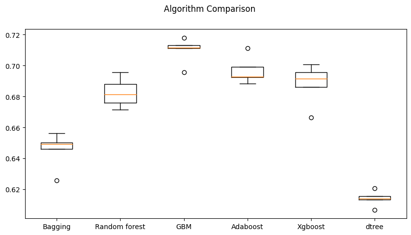

```python
# Plotting boxplots for CV scores of all models defined above
fig = plt.figure(figsize=(10, 5))

fig.suptitle("Algorithm Comparison")
ax = fig.add_subplot(111)

plt.boxplot(results1)
ax.set_xticklabels(names)

plt.show()
```

#### Model Benchmarking Results - Undersampled Data

Boosting models again outperformed simpler methods, even with a smaller training sample size. These were the top 3 models based on performance:

1. **Gradient Boosting (GBM):**
- CV: 0.71
- Validation: 0.76
2. **AdaBoost:**
- CV: 0.697
- Validation: 0.75
3. **XGBoost:**
- CV: 0.688
- Validation: 0.74

Other Notes:

- GBM had the highest F1 score on both training and validation sets, indicating that it is the most stable and consistent performer across all data strategies.
- AdaBoost and XGBoost followed closely behind and showed narrow interquartile ranges (IQRs) in cross-validation, indicating low variability and reliable performance.
- Random Forest, while decent, did not outperform the boosting models and had more spread in performance.
- Bagging and Decision Tree had the lowest scores, reinforcing that simpler models are less effective in this use case.

## Hyperparameter Tuning

#### Model Selection for Hyperparameter Tuning

After benchmarking six classifiers across original, oversampled, and undersampled datasets, I selected the following four models for tuning based on their strong F1 scores, low cross-validation variance, and consistent validation performance:

1. **AdaBoost (Oversampled)**
2. **Random Forest (Undersampled)**
3. **Gradient Boosting (Oversampled)**
4. **XGBoost (Oversampled)**

**Why these models?:**

- High F1 scores -- Strong balance of Precision and Recall.
- Low variance across CV folds -- Stable and reliable.
- Strong validation scores -- Good generalization, minimal overfitting.

**Why these sampling strategies?:**

- **Boosting models** (AdaBoost, GBM, XGBoost) benefit from **oversampling** to learn from both classes equally.
- **Random Forest** performs well even with **undersampling**, enabling faster training while still capturing key patterns.

### Tuning AdaBoost Using Oversampled Data

```python
%%time

# Defining the model
Model = AdaBoostClassifier(random_state=1)

# Parameter grid to pass in RandomizedSearchCV
param_grid = {
    "n_estimators": [50, 100, 150, 200],
    "learning_rate": [0.01, 0.05, 0.1, 0.2, 0.5],
    "estimator": [
        DecisionTreeClassifier(max_depth=1, random_state=1),
        DecisionTreeClassifier(max_depth=2, random_state=1),
        DecisionTreeClassifier(max_depth=3, random_state=1)
    ]
}

# Calling RandomizedSearchCV
randomized_cv = RandomizedSearchCV(
    estimator=Model,
    param_distributions=param_grid,
    n_iter=50,
    n_jobs=-1,
    scoring=scorer,          # Using f1_score as defined earlier
    cv=5,                    # 5-fold cross-validation
    random_state=1
)

# Fitting parameters in RandomizedSearchCV on oversampled training data
randomized_cv.fit(X_train_oversampled, y_train_oversampled)

print("Best parameters are {} with CV score={}".format(
    randomized_cv.best_params_, randomized_cv.best_score_
))
```

```
Best parameters are {'n_estimators': 200, 'learning_rate': 0.1, 'estimator': DecisionTreeClassifier(max_depth=3, random_state=1)} with CV score=0.791770361085057
CPU times: user 16.8 s, sys: 1.48 s, total: 18.2 s
Wall time: 13min 14s
```

**Best hyperparameters found:**

- n_estimators: 200
- learning_rate: 0.1
- estimator: DecisionTreeClassifier with max_depth=3

```python
# Setting the best parameters manually
tuned_ada = AdaBoostClassifier(
    n_estimators=200,
    learning_rate=0.1,
    estimator=DecisionTreeClassifier(max_depth=3, random_state=1)
)
# Fitting the tuned model on the oversampled training data
tuned_ada.fit(X_train_oversampled, y_train_oversampled)
```

```
AdaBoostClassifier(estimator=DecisionTreeClassifier(max_depth=3,
                                                    random_state=1),
                   learning_rate=0.1, n_estimators=200)
```

```python
# Evaluate performance on the training (oversampled) data
ada_train_perf = model_performance_classification_sklearn(tuned_ada, X_train_oversampled, y_train_oversampled)
ada_train_perf

print("\nAdaBoost - Performance on Oversampled Training Data:\n")
display(ada_train_perf)
```

```
AdaBoost - Performance on Oversampled Training Data:
```

|  | Accuracy | Recall | Precision | F1 |
| --- | --- | --- | --- | --- |
| 0 | 0.801729 | 0.818182 | 0.792117 | 0.804938 |

```python
# Evaluate performance on the validation (unseen) data
ada_val_perf = model_performance_classification_sklearn(tuned_ada, X_val, y_val)
ada_val_perf

print("\nAdaBoost - Performance on Validation Data:\n")
display(ada_val_perf)
```

```
AdaBoost - Performance on Validation Data:
```

|  | Accuracy | Recall | Precision | F1 |
| --- | --- | --- | --- | --- |
| 0 | 0.719872 | 0.807575 | 0.78056 | 0.793838 |

### Tuning Random Forest Using Undersampled Data

```python
%%time

# Defining model
Model = RandomForestClassifier(random_state=1)

# Parameter grid to pass into RandomizedSearchCV
param_grid = {
    "n_estimators": [50, 100, 150, 200],  # Number of trees in the forest
    "min_samples_leaf": np.arange(1, 6),  # Min samples required at a leaf node
    "max_features": [np.arange(3, 18, 3), 'sqrt'],  # Max features to consider at each split
    "max_samples": np.arange(0.5, 1.0, 0.1)  # Fraction of samples used to train each tree
}

# Calling RandomizedSearchCV
randomized_cv = RandomizedSearchCV(
    estimator=Model,
    param_distributions=param_grid,
    n_iter=50,
    n_jobs=-1,
    scoring=scorer,
    cv=5,  # 5-fold cross-validation
    random_state=1
)

# Fitting parameters in RandomizedSearchCV on undersampled data
randomized_cv.fit(X_train_undersampled, y_train_undersampled)

print("Best parameters are {} with CV score={}:".format(
    randomized_cv.best_params_,
    randomized_cv.best_score_
))
```

```
Best parameters are {'n_estimators': 150, 'min_samples_leaf': 5, 'max_samples': 0.5, 'max_features': 'sqrt'} with CV score=0.7125902411652401:
CPU times: user 3.13 s, sys: 293 ms, total: 3.42 s
Wall time: 2min 11s
```

**Best hyperparameters found:**

- n_estimators = 150
- min_samples_leaf = 5
- max_features = 'sqrt'
- max_samples = 0.5

```python
# Defining the best model using tuned hyperparameters
tuned_rf2 = RandomForestClassifier(
    max_features='sqrt',
    random_state=1,
    max_samples=0.5,
    n_estimators=150,
    min_samples_leaf=5
)

# Fitting the model on undersampled training data
tuned_rf2.fit(X_train_undersampled, y_train_undersampled)
```

```
RandomForestClassifier(max_samples=0.5, min_samples_leaf=5, n_estimators=150,
                       random_state=1)
```

```python
# Evaluate model performance on the train data
rf2_train_perf = model_performance_classification_sklearn(
    tuned_rf2, X_train_undersampled, y_train_undersampled
)
rf2_train_perf

print("\nRandom Forest - Performance on Undersampled Training Data:\n")
display(rf2_train_perf)
```

```
Random Forest - Performance on Undersampled Training Data:
```

|  | Accuracy | Recall | Precision | F1 |
| --- | --- | --- | --- | --- |
| 0 | 0.772666 | 0.778322 | 0.769616 | 0.773944 |

```python
# Evaluate model performance on the validation data
rf2_val_perf = model_performance_classification_sklearn(tuned_rf2, X_val, y_val)
rf2_val_perf

print("\nRandom Forest - Performance on Validation Data:\n")
display(rf2_val_perf)
```

```
Random Forest - Performance on Validation Data:
```

|  | Accuracy | Recall | Precision | F1 |
| --- | --- | --- | --- | --- |
| 0 | 0.702864 | 0.712233 | 0.819229 | 0.761993 |

#### Observations on Tuning - Random Forest (Undersampled)

- F1 Score on validation set was 0.76, slightly lower than boosting models.
- Training F1 Score was 0.77, showing minimal overfitting and good stability.
- Validation Precision was strong (0.82), indicating the model effectively avoids false positives.
- Validation Recall was lower (0.71), which is a drawback for this use case where minimizing false negatives is important.
- Overall, performance was solid but did not exceed the tuned boosting models.

### Tuning Using Gradient Boosting With Oversampled Data

```python
%%time

# Defining model
Model = GradientBoostingClassifier(random_state=1)

# Defining the hyperparameters to tune
param_grid = {
    "n_estimators": np.arange(50, 201, 50),        # Number of boosting stages
    "learning_rate": [0.01, 0.05, 0.1, 0.2],       # Step size shrinkage
    "subsample": [0.8, 1.0],                       # % of samples used for fitting each base learner
    "max_features": ['sqrt', 'log2']               # Max features for best split
}

# RandomizedSearchCV setup
randomized_cv = RandomizedSearchCV(
    estimator=Model,
    param_distributions=param_grid,
    scoring=scorer,            # Using F1 score
    n_iter=50,                 # Number of random combinations to try
    n_jobs=-1,
    cv=5,                      # 5-fold cross-validation
    random_state=1
)

# Fitting the model on oversampled training data
randomized_cv.fit(X_train_oversampled, y_train_oversampled)

print("Best parameters are {} with CV score={}:".format(
    randomized_cv.best_params_,
    randomized_cv.best_score_
))
```

```
Best parameters are {'subsample': 0.8, 'n_estimators': 150, 'max_features': 'sqrt', 'learning_rate': 0.2} with CV score=0.7954521247148147:
CPU times: user 5.25 s, sys: 674 ms, total: 5.93 s
Wall time: 4min 56s
```

- **Best parameters found:**
  - n_estimators = 150
  - learning_rate = 0.2
  - subsample = 0.8
  - max_features = 'sqrt'

```python
# Define the best model using the tuned hyperparameters
tuned_gbm = GradientBoostingClassifier(
    max_features='sqrt',
    random_state=1,
    learning_rate=0.2,
    n_estimators=150,
    subsample=0.8
)

# Fit the model on the oversampled training data
tuned_gbm.fit(X_train_oversampled, y_train_oversampled)
```

```
GradientBoostingClassifier(learning_rate=0.2, max_features='sqrt',
                           n_estimators=150, random_state=1, subsample=0.8)
```

```python
# Evaluate model performance on the train data
gbm_train_perf = model_performance_classification_sklearn(
    tuned_gbm, X_train_oversampled, y_train_oversampled
)
gbm_train_perf

print("\nGradient Boosting - Performance on Oversampled Training Data:\n")
display(gbm_train_perf)
```

```
Gradient Boosting - Performance on Oversampled Training Data:
```

|  | Accuracy | Recall | Precision | F1 |
| --- | --- | --- | --- | --- |
| 0 | 0.803576 | 0.832956 | 0.786728 | 0.809182 |

```python
# Evaluate model performance on the validation data
gbm_val_perf = model_performance_classification_sklearn(tuned_gbm, X_val, y_val)
gbm_val_perf

print("\nGradient Boosting - Performance on Validation Data:\n")
display(gbm_val_perf)
```

```
Gradient Boosting - Performance on Validation Data:
```

|  | Accuracy | Recall | Precision | F1 |
| --- | --- | --- | --- | --- |
| 0 | 0.72089 | 0.817153 | 0.776583 | 0.796351 |

#### Observations on Tuning - Gradient Boosting (Oversampled)

- The model achieved strong performance on the training set, with high Accuracy, Precision, Recall, and F1 Score, indicating that it effectively learned the balanced patterns in the oversampled data.
- The model achieved a cross-validated F1 score (0.796), indicating strong performance during training with oversampled data.

### Tuning XGBoost Using Oversampled Data

```python
%%time

# Defining model
Model = XGBClassifier(random_state=1, eval_metric='logloss')

# Defining the hyperparameters to tune
param_grid = {
    'n_estimators': [50, 100, 150, 200],       # Number of boosting rounds
    'scale_pos_weight': [1],                   # 1 is fine here since data is already oversampled and balanced
    'learning_rate': [0.01, 0.05, 0.1, 0.2],   # Step size shrinkage
    'gamma': [0, 0.1, 0.3, 0.5],               # Minimum loss reduction to make a split
    'subsample': [0.7, 0.8, 1.0]               # Fraction of training samples for growing each tree
}

# RandomizedSearchCV setup
randomized_cv = RandomizedSearchCV(
    estimator=Model,
    param_distributions=param_grid,
    n_iter=50,
    n_jobs=-1,
    scoring=scorer,     # Using F1 score
    cv=5,               # 5-fold cross-validation
    random_state=1
)

# Fit the model on oversampled data
randomized_cv.fit(X_train_oversampled, y_train_oversampled)

print("Best parameters are {} with CV score={}:".format(
    randomized_cv.best_params_,
    randomized_cv.best_score_
))
```

```
Best parameters are {'subsample': 0.8, 'scale_pos_weight': 1, 'n_estimators': 150, 'learning_rate': 0.05, 'gamma': 0.1} with CV score=0.8017080193579454:
CPU times: user 3.02 s, sys: 353 ms, total: 3.37 s
Wall time: 2min 2s
```

**Best parameters found:**

- n_estimators: 150
- learning_rate: 0.05
- gamma: 0.1
- subsample: 0.8
- scale_pos_weight: 1
- CV F1 score: 0.802

```python
## Defining the best model using tuned hyperparameters
xgb2 = XGBClassifier(
    random_state=1,
    eval_metric='logloss',
    subsample=0.8,
    scale_pos_weight=1,
    n_estimators=150,
    learning_rate=0.05,
    gamma=0.1
)

# Fit the model on the oversampled training data
xgb2.fit(X_train_oversampled, y_train_oversampled)
```

```
XGBClassifier(base_score=None, booster=None, callbacks=None,
              colsample_bylevel=None, colsample_bynode=None,
              colsample_bytree=None, device=None, early_stopping_rounds=None,
              enable_categorical=False, eval_metric='logloss',
              feature_types=None, gamma=0.1, grow_policy=None,
              importance_type=None, interaction_constraints=None,
              learning_rate=0.05, max_bin=None, max_cat_threshold=None,
              max_cat_to_onehot=None, max_delta_step=None, max_depth=None,
              max_leaves=None, min_child_weight=None, missing=nan,
              monotone_constraints=None, multi_strategy=None, n_estimators=150,
              n_jobs=None, num_parallel_tree=None, random_state=1, ...)
```

```python
# Evaluate model performance on the train data
xgb2_train_perf = model_performance_classification_sklearn(
    xgb2, X_train_oversampled, y_train_oversampled
)
xgb2_train_perf

print("\nXGBoost - Performance on Oversampled Training Data:\n")
display(xgb2_train_perf)
```

```
XGBoost - Performance on Oversampled Training Data:
```

|  | Accuracy | Recall | Precision | F1 |
| --- | --- | --- | --- | --- |
| 0 | 0.822295 | 0.855788 | 0.802061 | 0.828054 |

```python
# Evaluate model performance on the validation data
xgb2_val_perf = model_performance_classification_sklearn(xgb2, X_val, y_val)
xgb2_val_perf

print("\nXGBoost - Performance on Validation Data:\n")
display(xgb2_val_perf)
```

```
XGBoost - Performance on Validation Data:
```

|  | Accuracy | Recall | Precision | F1 |
| --- | --- | --- | --- | --- |
| 0 | 0.724524 | 0.823248 | 0.77739 | 0.799662 |

#### Observations on Tuning - XGBoost (Oversampled)

- XGBoost handled the oversampled dataset well and is a robust, high-performing candidate for final model selection.
- On the oversampled training set, we see high Precision, Recall (0.86 - Highest we've seen), and F1 Score (0.83).
- On the validation set, performance remained consistent, indicating good generalization and no overfitting.

## Model Performance Comparison & Final Selection

- In the next step, I will compile performance metrics for each of the four tuned models, for both the training and validation sets, and evaluate them based on F1 Score, Recall, Prioritization, and Accuracy.
- Using this analysis, I will choose a final model to implement.

```python
# Training performance comparison

models_train_comp_df = pd.concat(
    [
        gbm_train_perf.T,
        xgb2_train_perf.T,
        ada_train_perf.T,
        rf2_train_perf.T,
    ],
    axis=1,
)
models_train_comp_df.columns = [
    "Gradient Boosting (Oversampled Data)",
    "XGBoost (Oversampled Data)",
    "AdaBoost (Oversampled Data)",
    "Random Forest (Undersampled Data)",
]
print("\nTraining Performance Comparison:\n")
models_train_comp_df
```

```
Training Performance Comparison:
```

|  | Gradient Boosting (Oversampled Data) | XGBoost (Oversampled Data) | AdaBoost (Oversampled Data) | Random Forest (Undersampled Data) |
| --- | --- | --- | --- | --- |
| Accuracy | 0.803576 | 0.822295 | 0.801729 | 0.772666 |
| Recall | 0.832956 | 0.855788 | 0.818182 | 0.778322 |
| Precision | 0.786728 | 0.802061 | 0.792117 | 0.769616 |
| F1 | 0.809182 | 0.828054 | 0.804938 | 0.773944 |

#### Observations on Tuning Comparison - Training Performance:

- XGBoost (oversampled) outperforms in all performance metrics on the train data and proves to be the most balanced model option - F1 Score (0.83), Recall (0.86), Precision (0.8), and Accuracy (0.82)
- GBM (oversampled) is a close runner-up in performance across all train data metrics.
- AdaBoost (oversampled) lags slightly behind.
- Random Forest (undersampled) is clearly not performing as well as the boosting models.

```python
# Validation performance comparison

models_val_comp_df = pd.concat(
    [
        gbm_val_perf.T,
        xgb2_val_perf.T,
        ada_val_perf.T,
        rf2_val_perf.T,
    ],
    axis=1,
)
models_val_comp_df.columns = [
    "Gradient Boosting (Oversampled Data)",
    "XGBoost (Oversampled Data)",
    "AdaBoost (Oversampled Data)",
    "Random Forest (Undersampled Data)",
]
print("\nValidation Performance Comparison:\n")
models_val_comp_df
```

```
Validation Performance Comparison:
```

|  | Gradient Boosting (Oversampled Data) | XGBoost (Oversampled Data) | AdaBoost (Oversampled Data) | Random Forest (Undersampled Data) |
| --- | --- | --- | --- | --- |
| Accuracy | 0.720890 | 0.724524 | 0.719872 | 0.702864 |
| Recall | 0.817153 | 0.823248 | 0.807575 | 0.712233 |
| Precision | 0.776583 | 0.777390 | 0.780560 | 0.819229 |
| F1 | 0.796351 | 0.799662 | 0.793838 | 0.761993 |

#### Evaluating Train & Validation Deltas

I want to compare the differences between training and validation metrics for GBM (oversampled) and XGBoost (oversampled), as the ideal model should perform similarly on both data sets.

```python
# Calculate deltas (Validation - Training) for each metric
gbm_delta = gbm_val_perf.T - gbm_train_perf.T
xgb_delta = xgb2_val_perf.T - xgb2_train_perf.T

# Combine into one DataFrame
delta_compare = pd.concat([gbm_delta, xgb_delta], axis=1)
delta_compare.columns = ['GBM Delta', 'XGBoost Delta']

# Display the delta table
print("\nDelta in Performance (Validation - Training):\n")
display(delta_compare)
```

```
Delta in Performance (Validation - Training):
```

|  | GBM Delta | XGBoost Delta |
| --- | --- | --- |
| Accuracy | -0.082686 | -0.097771 |
| Recall | -0.015803 | -0.032540 |
| Precision | -0.010145 | -0.024672 |
| F1 | -0.012831 | -0.028392 |

### Check Model Against Test Data

- To validate my selection of XGBoost (oversampled), I'm checking its performance against the test data set.
- I'm also checking its closest competitor, GBM (oversampled).

```python
# Evaluate the final model (XGBoost with oversampled data) on the test set
test_xgboost = model_performance_classification_sklearn(xgb2, X_test, y_test)
test_xgboost

print("\nXGBoost (Oversampled) - Performance on Test Data:\n")
display(test_xgboost)
```

```
XGBoost (Oversampled) - Performance on Test Data:
```

|  | Accuracy | Recall | Precision | F1 |
| --- | --- | --- | --- | --- |
| 0 | 0.755556 | 0.861057 | 0.791367 | 0.824742 |

```python
# Evaluate the GBM (oversampled) model on the test set
test_gbm = model_performance_classification_sklearn(tuned_gbm, X_test, y_test)
test_gbm

print("\nGradient Boosting (Oversampled) - Performance on Test Data:\n")
display(test_gbm)
```

```
Gradient Boosting (Oversampled) - Performance on Test Data:
```

|  | Accuracy | Recall | Precision | F1 |
| --- | --- | --- | --- | --- |
| 0 | 0.756863 | 0.857143 | 0.794918 | 0.824859 |

#### Confirmed - XGBoost (Oversampled) is Best Model For Predicting Visa Approval:

- Higher Recall (0.86) means XGBoost is catching slightly more true positives.
- In a visa approval use case, that means fewer qualified applicants are wrongly denied.
- Precision is nearly tied between the two models, so XGBoost is not compromising on false positives.
- F1 scores are almost identical, showing both models balance Precision and Recall well -- but XGBoost is better on Recall, which matters most in this context.

**XGBoost (Oversampled) is the final model choice.**

#### Evaluate Feature Importance

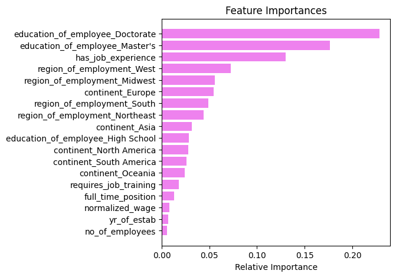

```python
feature_names = X_train.columns
importances = xgb2.feature_importances_  # Extract feature importances from the XGBoost model
indices = np.argsort(importances)

plt.figure(figsize=(5, 5))
plt.title("Feature Importances")
plt.barh(range(len(indices)), importances[indices], color="violet", align="center")
plt.yticks(range(len(indices)), [feature_names[i] for i in indices])
plt.xlabel("Relative Importance")
plt.show()
```

#### Feature Importance Interpretation

Top Predictors of Visa Certification:

1. **Doctorate & Master's Degrees** -- Applicants with advanced degrees had the highest likelihood of certification, confirming earlier EDA insights that higher education levels correlate strongly with approval.
2. **Has Job Experience** -- Prior work experience was a key driver of approval, consistent with EDA trends showing significantly higher certification rates among experienced applicants.
3. **Region of Employment (West, Midwest)** -- Geographic regions like the West and Midwest contributed more to approval decisions, aligning with slight regional wage advantages and demand concentrations noted in EDA.
4. **Continent (Europe)** -- Applicants from Europe saw higher approval rates compared to other continents—particularly Asia, North America, and South America—reinforcing observed geographic patterns.

Less Influential Features:

1. **Requires Job Training** -- This feature had limited impact, likely due to the small number of applicants requiring training. It may also carry less predictive weight compared to stronger qualifiers like education or experience.
2. **Normalized Wage (Originally Unit of Wage), Year of Establishment, Number of Employees**
- These numeric employer-related features showed minimal predictive influence, reflecting low correlations observed during EDA.
- The normalized wage didn’t sharply distinguish certified from denied cases.
- Year of establishment and company size may signal organizational stability but appeared less decisive than applicant qualifications.
- Overall, visa approval outcomes were shaped more by applicant-level factors than employer scale.

## Executive Summary & Recommendations

As the number of visa applications continues to rise annually, the need for scalable, efficient, and equitable processing has become critical. The EasyVisa project applied machine learning to streamline the U.S. Office of Foreign Labor Certification’s (OFLC) visa adjudication process. After testing multiple classifiers and resampling strategies, **XGBoost trained on oversampled data** emerged as the best-performing model, offering a strong balance of Precision and Recall, especially in identifying qualified applicants.

### Recommendations

#### Model Deployment & Workflow Integration

1. **Adopt the Final XGBoost Model**  
   Deploy it within OFLC’s pipeline to automatically flag high-likelihood approvals and surface edge cases for human review.
2. **Use the Model to Prioritize Reviews**  
   Fast-track low-risk applications and route complex or borderline cases for additional review to improve throughput.
3. **Leverage Risk Scores for Smarter Triage**  
   Use XGBoost’s probability scores (not just binary outcomes) to create a risk-ranking system for more efficient queue management.

#### Fairness, Auditability & Continuous Improvement

4. **Promote Fairness via High Recall**  
   Maintain high recall to reduce false denials and uphold equity in the review process.
5. **Compare Model vs. Human Outcomes**  
   Regularly audit prediction mismatches to identify inconsistencies and potential training or policy gaps.
6. **Incorporate Reviewer Feedback Loops**  
   Enable human reviewers to flag cases for retraining or model refinement over time.
7. **Monitor Model Health**  
   Track performance metrics, retrain with fresh data, and monitor for drift or demographic bias.

#### Policy Alignment & Process Optimization

8. **Prioritize Education & Experience**  
   Emphasize these features in review criteria, as they were the most predictive indicators of approval.
9. **De-emphasize Employer Characteristics**  
   Reduce reliance on features like company size, founding year, or wage unit, which had little predictive power.
10. **Support Underserved Regions**  
    Consider outreach or educational resources for regions with lower approval rates (e.g., South and North America).

#### Data Infrastructure & Enrichment

11. **Standardize and Automate Data Pipelines**  
    Ensure clean and consistent inputs with automated normalization and encoding workflows.
12. **Improve Employer Data Quality**  
    Encourage more consistent reporting of fields like `requires_job_training` and `unit_of_wage`.
13. **Enrich Dataset for Deeper Insights**  
    Consider adding features like job codes, industry type, company status, or denial reasons to uncover deeper patterns and improve future models.